# Build and Deploy ML App in Dev with Docker Compose

# Introduction

As an MLOps or AI/ML engineer on the AI Platform Engineering team, the mission is to **simulate a real-world machine learning application** in a development environment by automating its deployment using **Docker Compose**. This setup offers a fast and reliable way to build a **local development environment** and **streamline onboarding** for new data scientists and ML engineers.

Create a local dev/test environment that includes:

- **Model training and tracking** with MLflow
- **Model serving** using FastAPI
- **User interaction** through Streamlit

Such an environment enables teams to **test integrations**, **debug workflows**, and **ensure reproducibility** before moving to production systems like **Kubernetes**.

**Workflow steps:**

1. Run `pipeline.py` to execute the pipeline and generate artifacts.
2. Access the **MLflow UI** at http://localhost:5555.
3. Open the **FastAPI documentation** at http://localhost:8000/docs.
4. Launch the **Streamlit app** at http://localhost:8501.
5. Streamlit connects to FastAPI to send requests and display predictions.
6. All services run together using `docker-compose up`.

Using the powerful tool **Docker Compose** for local deployment, testing, and development allows to:

- **Create consistent dev/test environments** across machines
- **Share portable ML applications** with teammates
- **Validate service integrations** before scaling to Kubernetes
- **Work like a real AI/ML Platform Engineering team**

We’re not just containerizing components — we’re simulating a production-grade architecture in a controlled local environment.

## Understanding the Application Stack and the ML Workflow

See the flowchart below. The setup begins with a **user interacting with a front-end application**, which in this case is **Streamlit**. Streamlit serves as the web interface and sends **API requests to the backend**.

We cannot directly run a model from a pickle file — instead, we **wrap the trained model with FastAPI**, which exposes specific **prediction endpoints**. These endpoints are what the Streamlit front end calls to request model predictions.

The figure below illustrates the **deployment stack**, which closely resembles a **production environment**.

During model packaging and training, several processes take place in the **development environment**:

- We **automate model training pipelines** that use input data (e.g., feature datasets) to train the model and generate a pickle file.
- While this occurs, we **log experiments and metrics in MLflow**, which allows data scientists to track experiments, perform EDA, and manage model versions.

[figure not shown]

In this setup, we want **MLflow**, **FastAPI**, and **Streamlit** all running together — but they can also be executed **independently** when needed.

[figure not shown]

# Model Development

We can find different real datasets on the [UCI Machine Learning repository](https://archive.ics.uci.edu/) which are processed and cleaned before and ready to feed Machine Learning algorithms. I found [Energy Efficiency Data Set](https://archive.ics.uci.edu/ml/datasets/Energy+efficiency) useful for this course. Energy analysis are performed for 768 simulated building shapes with respect to 8 features including Wall Area, Overall Height, Glazing Area, Orientation.. to predict Heating Load and Cooling Load. The work has been published by Tsanas and Xifara 2012 on [Energy and Buildings Journal](https://www.sciencedirect.com/science/article/pii/S037877881200151X). The dataset can be used for both regression and classification. In this work, we apply binary classification on Heating Load that is the amount of heating that a building needs in order to maintain the indoor temperature at established levels.

## Packaged Model Development

These outputs serve as inputs to both **MLflow** (for experiment and model tracking) and **FastAPI** (for backend model inference).

The training script (`model_train.py`) is executed within the main pipeline (`pipeline.py`), which loads the data, triggers model training, and writes the outputs to the specified directories. Below is the relevant section of `pipeline.py`:

```
import subprocess
import sys

# Use the current environment's Python executable
python_executable = sys.executable
print(f"Current environment's Python executable: {python_executable}")

print('# ----------------------------------------------------------------------------------------------')
print('#                                1. Train the model                                             ')
print('# ----------------------------------------------------------------------------------------------')
subprocess.run([
    python_executable, "./model/model_train.py",
    "--config", "./model/configs/model_config.yaml",
    "--data", "./model/data/building_heating_load.csv",
    "--models-dir", "./model/pickles",
])
```

**Model Development Directory Structure**

[output not shown]

# MLflow

After the model development stage is complete, its outputs are fed into MLflow for experiment tracking. MLflow records model metrics, hyperparameters, artifacts, and performance plots. A script named `run_mlflow.py` inside the `mlflow` folder reads the outputs from `model_train.py` and logs the results to MLflow. Once `model_train.py` and the MLflow script run, the MLflow UI becomes available at `http://localhost:5555`.

The MLflow script (`run_mlflow.py`) is executed from the main pipeline (`pipeline.py`), which loads the YAML configuration file generated during training. Below is the relevant section of `pipeline.py`:

```
print('# ----------------------------------------------------------------------------------------------')
print('#                               2. Run MLflow                                                   ')
print('# ----------------------------------------------------------------------------------------------')
subprocess.run([
    python_executable, "mlflow/run_mlflow.py",
    "--config", "./model/configs/model_config.yaml",
    "--models-dir", "./model/pickles",
    "--mlflow-tracking-uri", "http://localhost:5555"
])
```

## Packaged MLflow

Running MLflow locally works for development, but for consistent collaboration across the team—using the same MLflow version, dependencies, and environment—a containerized setup is needed. This is where Docker Compose becomes useful.

MLflow provides a pre-built image, so we do not need to build it manually. A basic example of running MLflow using Docker is:

```
docker run -d --name mlflow -p 5555:5000 ghcr.io/mlflow/mlflow:latest mlflow server --host 0.0.0.0
```

This behavior can be captured in a `compose.yaml` file so it can be version-controlled and shared with the team. Everyone can then launch the exact same environment with a single command.

Docker Compose on Windows uses the `compose.yaml` naming convention. For MLflow, the file needs entries such as the service **name** (`mlflow_energy_load`), **image** (`ghcr.io/mlflow/mlflow:latest`), **port** mapping (`5555:5000`), **container_name**, and startup **command** (`mlflow server --host 0.0.0.0`). The resulting `compose.yaml` is:

```
services:
  mlflow_energy_load:
    image: ghcr.io/mlflow/mlflow:latest
    container_name: mlflow_energy_load
    ports:
      - "5555:5000"
    command: mlflow server --host 0.0.0.0
```

This Docker Compose file is triggered from the main pipeline (`pipeline.py`) using the following section:

```
print('# ----------------------------------------------------------------------------------------------')
print('#                                3. Run MLflow Docker Compose                                   ')
print('# ----------------------------------------------------------------------------------------------')
print("Starting docker compose services...")
subprocess.run([
    "docker", "compose", "-f", "./mlflow/compose.yaml", "up", "-d"
], check=True)
```

**MLflow Directory Structure**

```
pipeline.py
│
├── mlflow/
│   ├── run_mlflow.py
│   ├── compose.yaml
```

Once started, MLflow runs on http://localhost:5555, and the entire team can view the tracking UI consistently across machines. Here is mlflow's container:

[figure not shown]

Here is mlflow running on port 5555:

[figure not shown]

# Packaged FastAPI and Streamlit

We should follow a unified and centralized approach for both FastAPI and Streamlit, similar to how we use MLflow. In this setup, FastAPI loads the trained model (pickle file), receives input sent from the Streamlit UI, performs the prediction on the backend, and returns the result to Streamlit for display to the end-user.

This raises an important question: **Why not simply use Streamlit alone and skip FastAPI?** Below are the key reasons why using FastAPI together with Streamlit is the better approach.

**1. Separation of concerns (clean architecture)**

- **Streamlit = UI**
- **FastAPI = backend logic + ML inference**

This makes the system easier to maintain, test, and scale.

If model or preprocessing changes, we can update only the FastAPI backend— the UI does *not* need a redesign.

**2. Reliability & stability**

Streamlit is great for prototyping, but:

- It reloads the script whenever the user interacts.
- It reruns the Python file repeatedly.
- Large ML models may reload multiple times.

FastAPI runs the model **once at startup**, which is more stable.

**3. Performance**

FastAPI:

- Runs asynchronously
- Is very fast for API calls
- Handles multiple users at the same time

Streamlit is single-threaded and not optimized for serving fast inference to many users.

**4. Security**

APIs can implement:

- authentication
- rate limiting
- input validation
- logging

Streamlit doesn’t provide strong backend security features.

Companies require secure interfaces for ML services → FastAPI fits.

**5. Scalability & Production Deployment**

Companies need:

- Dockerized microservices
- Kubernetes support
- Load balancing
- Deployment pipelines

FastAPI can be packaged as a clean microservice.

Streamlit is mainly a **frontend visualization tool**, not a backend service.

**6. Multiple clients can use the same model**

With FastAPI, *one backend* can serve:

- Streamlit UI
- mobile apps
- internal dashboards
- monitoring services

This is extremely useful in enterprise.

If the model sits inside Streamlit, only the Streamlit app can use it.

**7. Streamlit is meant for UI, not backend computation**

Streamlit was built as: ✔ rapid prototyping ✔ interactive dashboards ✔ demos

Not as: ✘ inference engine ✘ heavy ML backend

FastAPI was specifically designed for backend APIs + ML serving.

## Building Docker Images for FastAPI and Streamlit

While we have Docker images for MLflow, we don’t yet have pre-built images for FastAPI and Streamlit, so we need to create them ourselves. Using **Docker Compose**, we can define and build both images in a structured way.

The general process is:

1. Build each image and optionally tag it for your Docker Hub registry (use Docker Hub username).
2. Specify the **build context** and **Dockerfile path** in the Docker Compose file to ensure the images are created correctly.
3. The context defines the folder used for building the image, and the Dockerfile contains the instructions for the image.

Section below shows Docker files for FastAPI and Streamlit. Each has its own code and requited packages to install:

### FastAPI Dockerfile

This Dockerfile creates an image for the FastAPI backend:

```
FROM python:3.11-slim

WORKDIR /app

# Copy only FastAPI app code
COPY fastapi/ /app/

# Copy the requirements file
COPY fastapi/requirements.txt /app/requirements.txt

# Install dependencies
RUN pip install -r requirements.txt

# Copy trained model pickle files
COPY ../model/pickles/*.pkl /app/model/pickles/

# Expose FastAPI port
EXPOSE 8000

# Run the FastAPI app
CMD ["uvicorn", "main:app", "--host", "0.0.0.0", "--port", "8000"]
```

**Explanation:**

- **FROM python:3.11-slim**: Uses a lightweight Python image.
- **WORKDIR /app**: Sets working directory in the container.
- **COPY**: Copies only necessary files to minimize image size.
- **RUN pip install -r requirements.txt**: Installs all dependencies.
- **EXPOSE 8000**: Makes FastAPI accessible on port 8000.
- **CMD**: Starts the FastAPI server using Uvicorn.

**FastAPI Directory Structure**

```
pipeline.py
│
├── fastapi/
│   ├── main.py
│   ├── pydantic_objects.py
│   ├── run_prediction.py
│   ├── requirements.txt
├── Dockerfile
```

### Streamlit Dockerfile

This Dockerfile creates an image for the Streamlit frontend:

```
FROM python:3.9-slim

WORKDIR /app

# Copy only the Streamlit app code
COPY streamlit/ ./

# Install dependencies
RUN pip install -r requirements.txt

# Expose Streamlit port
EXPOSE 8501

# Run the Streamlit app
CMD ["streamlit", "run", "app.py", "--server.address=0.0.0.0"]
```

**Explanation:**

- **FROM python:3.9-slim**: Lightweight Python image for the frontend.
- **WORKDIR /app**: Container working directory.
- **COPY**: Copies only Streamlit app files.
- **RUN pip install -r requirements.txt**: Installs all app dependencies.
- **EXPOSE 8501**: Streamlit runs on port 8501.
- **CMD**: Starts the Streamlit app and listens on all interfaces.

**Streamlit Directory Structure**

```
pipeline.py
│
├── streamlit/
│   ├── app.py
│   ├── requirements.txt
│   ├── Dockerfile
```

- The FastAPI image serves as the backend, loading the ML model and handling prediction requests.
- The Streamlit image serves as the frontend, providing a UI and sending requests to FastAPI.
- Docker Compose allows us to define, build, and run both images together with proper port mapping.

### Trigger Docker Compose

Once we have separate Dockerfiles for FastAPI and Streamlit, the next step is to create a Docker Compose YAML file to orchestrate both services together. This file defines how the FastAPI backend and the Streamlit frontend run and interact.

```
services:
  fastapi:
    image: mrezvandehy/fastapi_with_docker
    container_name: fastapi_energy_load
    build:
      context: "."
      dockerfile: "Dockerfile"
    ports:
      - "8000:8000"  # Expose FastAPI on port 8000

  streamlit:
    image: mrezvandehy/streamlit_with_docker
    container_name: streamlit_energy_load
    build:
      context: "."
      dockerfile: "./streamlit/Dockerfile"
    ports:
      - "8501:8501"  # Expose Streamlit on port 8501
    environment:
      KEY: value
```

**Explanation:**

- **fastapi service**: Builds and runs the FastAPI backend, exposing port 8000.
- **streamlit service**: Builds and runs the Streamlit frontend, exposing port 8501 and optionally using environment variables.
- **build context & dockerfile**: Specify the directory and Dockerfile for each service so Docker Compose knows how to build the images.

This Docker Compose setup can be triggered programmatically from the main pipeline (`pipeline.py`) using the following code:

```
print('# ----------------------------------------------------------------------------------------------')
print('#                       4. Run Docker Compose for FastAPI & Streamlit                             ')
print('# ----------------------------------------------------------------------------------------------')
print("Starting Docker Compose services...")
subprocess.run([
    "docker", "compose", "-f", "compose.yaml", "up", "-d"
], check=True)
```

**Explanation:**

- This snippet runs `docker compose up -d` on the specified YAML file, starting both FastAPI and Streamlit containers in detached mode.
- Using the pipeline ensures the services are started automatically as part of your workflow.

## View Created Container and Images

Here are created containers for FastAPI and Streamlit:

[figure not shown]

Here are images created for Streamlit and FastAPI:

[figure not shown]

The FastAPI is available on port 8000: http://localhost:8000/docs#/

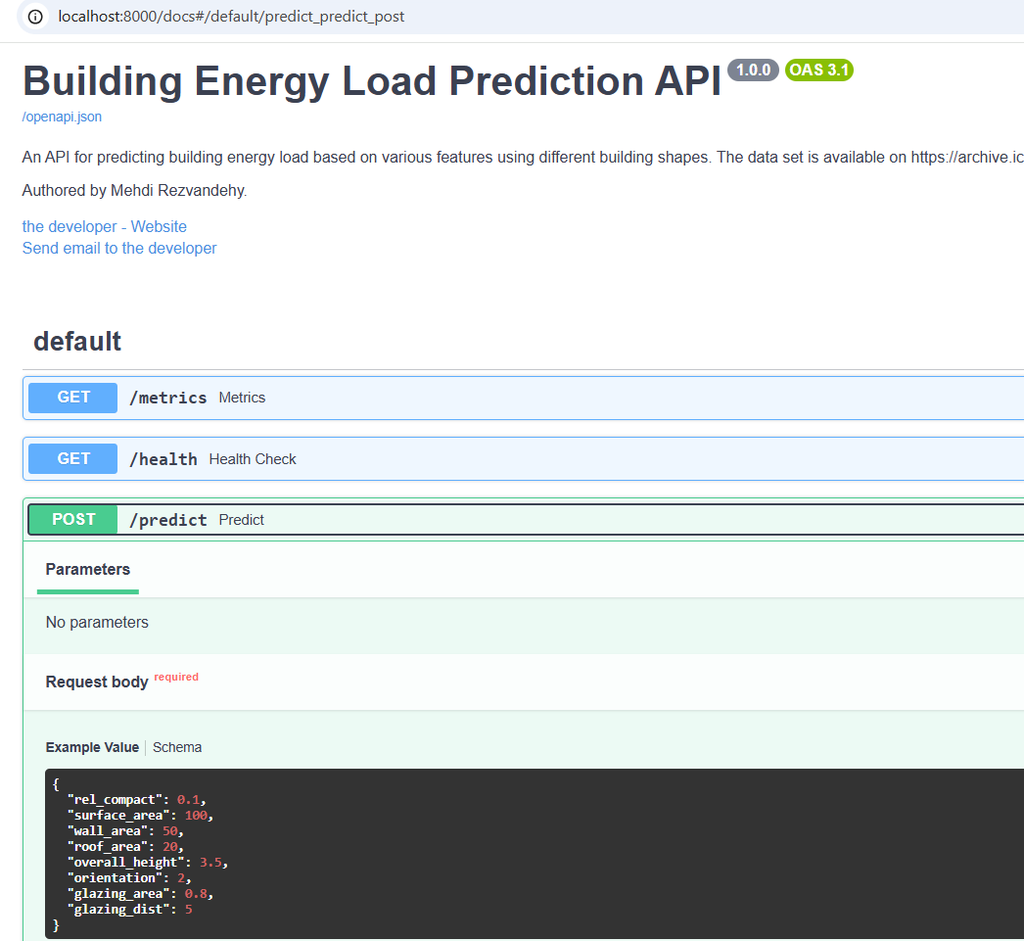

The Streamlit is available on port 8501: http://localhost:8501/

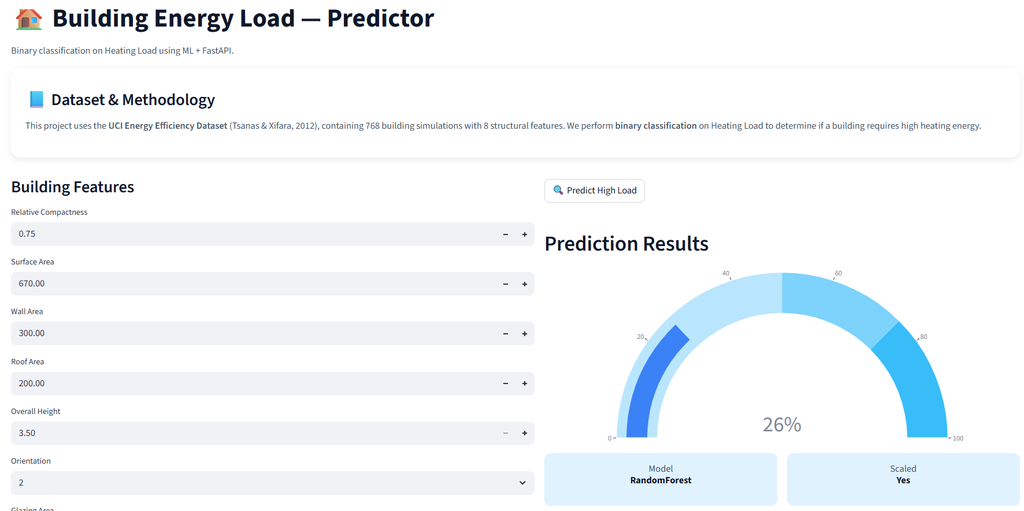

- `docker volume rm $(docker volume ls -q)`
- `docker rmi -f $(docker images -q)`